# beatochess no. 14 (November 2025)

### 3.2.9 Palguyev =0046.10e4a3 (2004). Cook (VH)

**1… Nf2+** cooks the study.

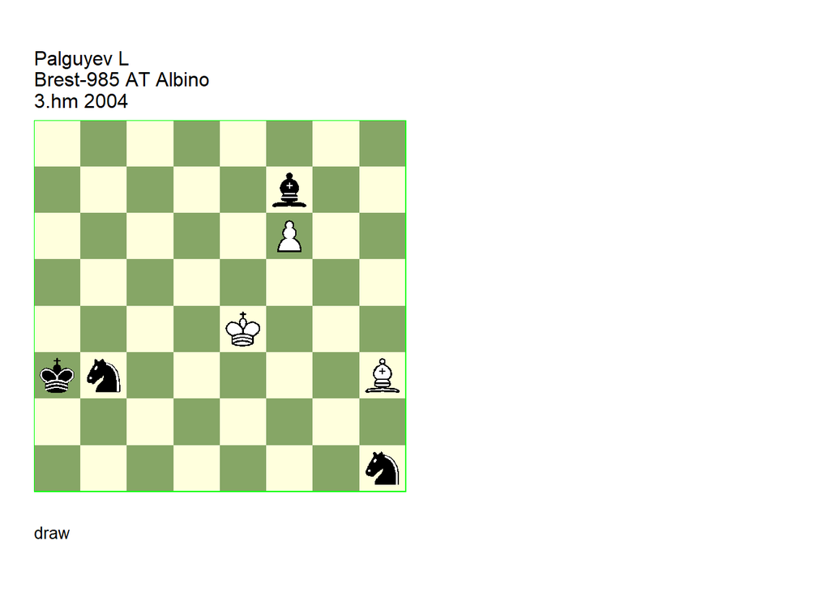

GBR: =0046.10e4a3 U3 FEN: 8/5b2/5P2/8/4K3/kn5B/8/7n w - - 0 1

Albino=51-52 Albino/7-8 2005. U3: Hergert=V 10/11/2025 . **1. Bg2! Ng3+** (1… Nf2+! **cook** VH 2. Ke5 Nd3+ 3. Kd6 Na5 4. Ke7 Ne5 5. Bh3 Bh5 6. Be6 Ng6+ -+ TB DTZ 23 ) **2. Kf4 Ne2+ 3. Ke5 Nd2 4. Kd6 Nc4+ 5. Ke7 Ne5 6. Kd6 Ng6 7. Bd5 1/2-1/2**.

Yes, the white king is in a check. **1. Kh4** cooks the study.

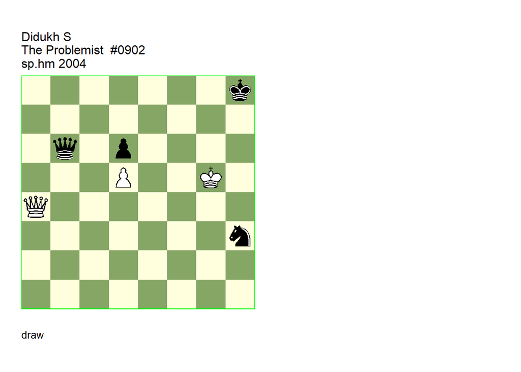

GBR: =4003.11g5h8 U1 FEN: 7k/8/1q1p4/3P2K1/Q7/7n/8/8 w - - 0 1

The Problemist=1 The Problemist/1 2005 (EG#16247). U1: Hergert=V beatochess 09/11/2025. **1. Kh5!** (1. Kh4? Qe3 2. Qd7 (2. Qa8+! **cook** VH 2… Kg7 3. Qb7+ Kg6 4. Qb1+ Kf6 5. Qb8 Ke5 6. Qe8+ Kd4 7. Qa4+ Kxd5 8. Qa8+ Kd4 9. Qa4+ Ke5 10. Qe8+ Kf4 11. Qf8+ Ke4 12. Qxd6!1) 2… Qh6+ 3. Kg4 Qg7+) (1. Kf5? Qb1+ 2. Ke6 Qg6+ 3. Kd7 Ng5) **1… Qe3** (1… Qg1 main 2. Qe8+! (2. Qh4? Qg2 3. Qd8+ Qg8 4. Qf6+ Qg7 5. Qf5 Qh7+) 2… Qg8 3. Kh6! Nf4 (3… Qxe8 main ) (3… Nf2 main 4. Qd7! Qf8+ 5. Kg6 Qg8+ 6. Kh6 Ng4+ 7. Qxg4 Qxg4) 4. Qd8! Nxd5 (4… Qxd8 main ) 5. Qf6+! (5. Qxd6? Qg7+ 6. Kh5 Nf6+ 7. Kh4 Qg4#) 5… Nxf6) (1… Qc7 2. Qe8+ Kg7 3. Qg6+ Kf8 4. Kh4) **2. Qh4!** (2. Qa1+? Kg8 3. Qf6 Qe2+ 4. Kh6 (4. Kh4 Qf2+) 4… Qe5! 5. Qg6+ Kf8 6. Qf5+! Ke7! 7. Qxh3 Qh8+) **2… Kh7** (2… Kg7 main 3. Qg3+! (3. Qg4+? Kf6) (3. Qd4+? Qe5+! (3… Qxd4?) ) 3… Qxg3) (2… Kg8 3. Qd8+ Kf7 4. Qd7+ Qe7 5. Qf5+ Qf6 6. Qd7+) (2… Qf3+ 3. Kg6+ Kg8 4. Qh7+ Kf8 5. Qh8+ Ke7 6. Qh4+ Kd7 7. Qa4+) **3. Qe4+!** (3. Kg4+? Kg7 4. Qxh3 Qxh3+) **3… Qxe4 1/2-1/2**.

### 3.2.11 Pogosyants =0034.21d5b7 (1984). Modification (VH)

Volker’s modification turns the cook into the mainline, which also shows a positional draw.

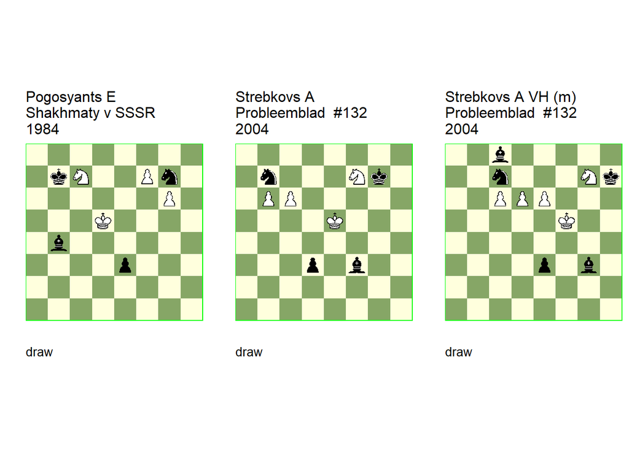

GBR: =0034.21d5b7 U4 FEN: 8/1kN2Pn1/6P1/3K4/1b6/4p3/8/8 w - - 0 1

Shakhmaty v SSSR/9. U4: Haworth=G Bleicher=E HHdbIV#52898 1-11-2009. **1. Nb5!** (1. Ne8? Bf8!) **1… e2 2. Nd6+ Bxd6 3. Kxd6 e1=B!** (3… e1=Q 4. f8=Q Qb4+ 5. Kd7! Qxf8) **4. f8=Q** (4. Kc5! **cook** GH/EB 4… Ne6+ 5. Kc4) **4… Bb4+ 5. Ke5 Bxf8 6. Kf6 Nh5+ 7. Kg5 Ng3 8. Kf6 Nh5+ 9. Kg5 Ng7 10. Kf6 Nh5+ 11. Kg5 1/2-1/2**.

GBR: =0034.21e5g7 AN U1 U4 FEN: 8/1n3Nk1/1PP5/4K3/8/3p1b2/8/8 w - - 0 1

= Pogosyants=E d5b7 1984. Probleemblad=1 Probleemblad/1-2. U1: Probleemblad=3 5-6/2004 U4: Haworth=G Bleicher=E HHdbIV#71304 25-10-2009. **1. c7** (1. cxb7! **cook** 1… Bxb7 2. Nd6! d2 3. Nf5+ Kf7 4. Ne3) (1. Nd6! **cook** 1… Bxc6 (1… Nxd6 2. Kxd6 d2 3. b7 d1=Q+ 4. Kc7 Qc2 5. b8=Q Qxc6+ 6. Kd8) 2. Nc4 Bb5 3. Nd2 Kf7 4. Kd4 Ke7 5. Ne4 Kd7 6. Nf2 d2 7. Kc3) **1… Bg4 2. Ng5!** (2. Nd8? Bc8!) **2… d2 3. Ne6+ Bxe6 4. Kxe6 d1=B!** (4… d1=Q 5. c8=Q Qg4+ 6. Ke7! Qxc8) **5. c8=Q** (5. Kf5! **cook** GH/EB 5… Ba4 6. c8=Q Nd6+ 7. Ke6 Nxc8 8. b7 Bd7+ (8… Bc6 9. b8=Q Nb6) ) **5… Bg4+ 6. Kd5 Bxc8 7. Kc6 Na5+ 8. Kb5 Nb3 9. Kc6 Na5+ 10. Kb5 Nb7 11. Kc6 Na5+ 12. Kb5 1/2-1/2**.

GBR: =0064.31f5h7 (m) FEN: 2b5/2n3Nk/2PPP3/5K2/8/4p1b1/8/8 w - - 0 1

modification: Hergert=V beatochess 09/11/2025. **1. d7 Bxd7 2. exd7** (2. cxd7? Bh4) **2… Bh4 3. Nh5!** (3. Ne8? Bd8) **3… e2 4. Nf6+ Bxf6 5. Kxf6 e1=B!** ( 5… e1=Q 6. d8=Q Qh4+ 7. Kf7 Qxd8) **6. Kg5!** (6. d8=Q? Bh4+ 7. Ke5 Bxd8 8. Kd6 Nb5+ 9. Kc5 Nc3 10. Kd6 Ba5! -+) **6… Ne6+ 7. Kf6!** (7. Kf5? Nd4+) ( 7. Kg4? Ba5) **7… Nc7 8. Kg5!1 1/2-1/2**.

### 3.2.12 Vlasenko +0302.11a2b6 (2005). Cook (VH), correction (BN)

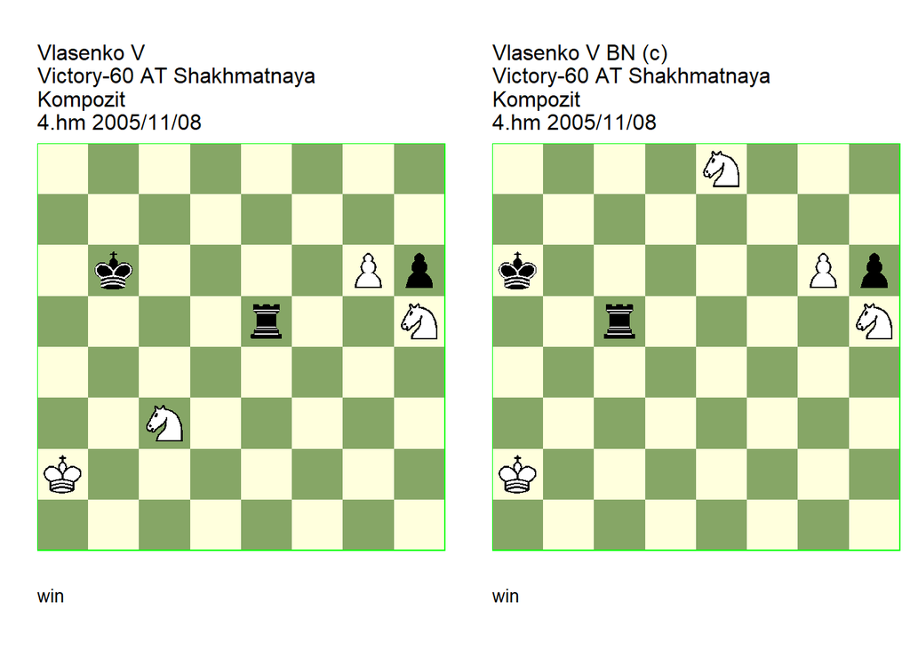

GBR: +0302.11a2b6 U2 FEN: 8/8/1k4Pp/4r2N/8/2N5/K7/8 w - - 0 1

Shakhmatnaya Kompozitsia=67 (EG#15994). U2: Hergert=V beatochess 03/11/2025.. **1. g7 Rg5 2. Nd5+!** (2. Ne4! ! **cook** VH TB DTZ 115 ) **2… Kc5 3. Ndf6 Rxg7 4. Nxg7 h5 5. Ne6+! Kd6 6. Ng5 Ke5 7. Nfh7 Kf4 8. Nh3+ Kg3 9. N7g5 1-0**.

GBR: +0302.11a2a6 (c) FEN: 4N3/8/k5Pp/2r4N/8/8/K7/8 w - - 0 1

correction: Neuenschwander=B beatochess 11/11/2025. **1. g7 Rg5 2. Nc7+** (2. Kb3? Kb6! 3. Kc4 Kc6 4. Kd4 Rg1 = TB ) **2… Kb6 3. Nd5+ Kc5** (3… Kb5 4. Kb3 +- TB DTZ 109 ) **4. Ndf6 Rxg7 5. Nxg7 h5 6. Ne6+ Kd6 7. Ng5 Ke5 8. Nfh7 Kf4 9. Nh3+ Kg3 10. N7g5 1-0**.